# **COVID-19 pandemic in Armenia**

### Daily Covid 19 status

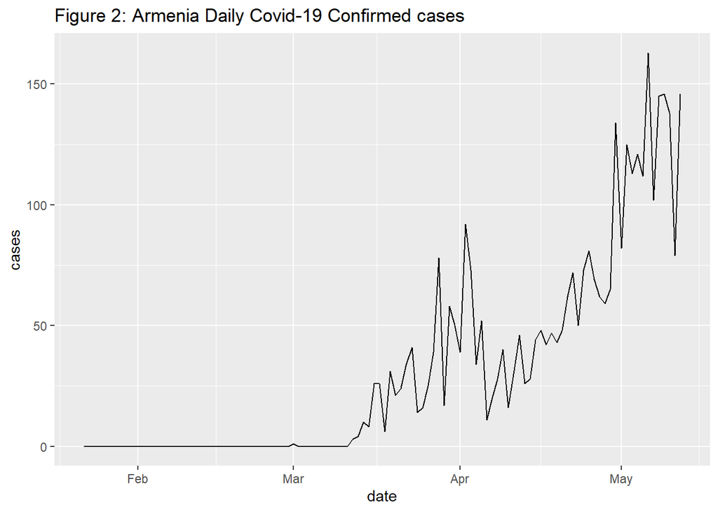

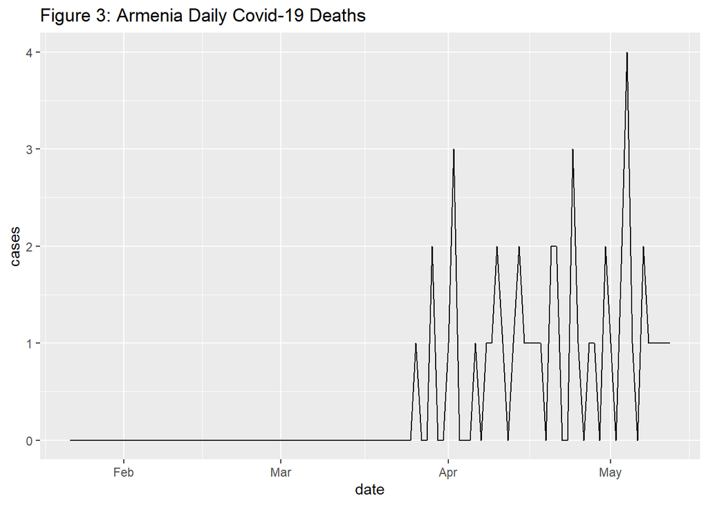

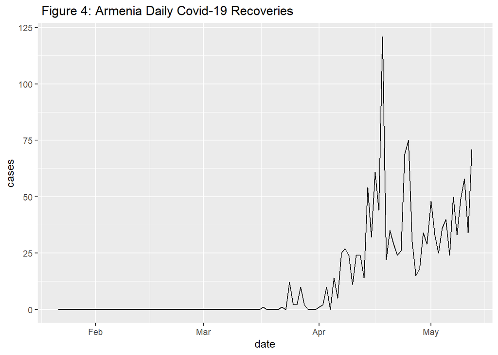

Figure 2 reveal that, there was high increased of covid 19 daily confirm cases since May. It shows, there were not any death until the end of March but after that their was very few daily deaths (Figure 3). In middle days of April, there were more covid 19 recoveries (Figure 4).

### Cumulative covid 19 status

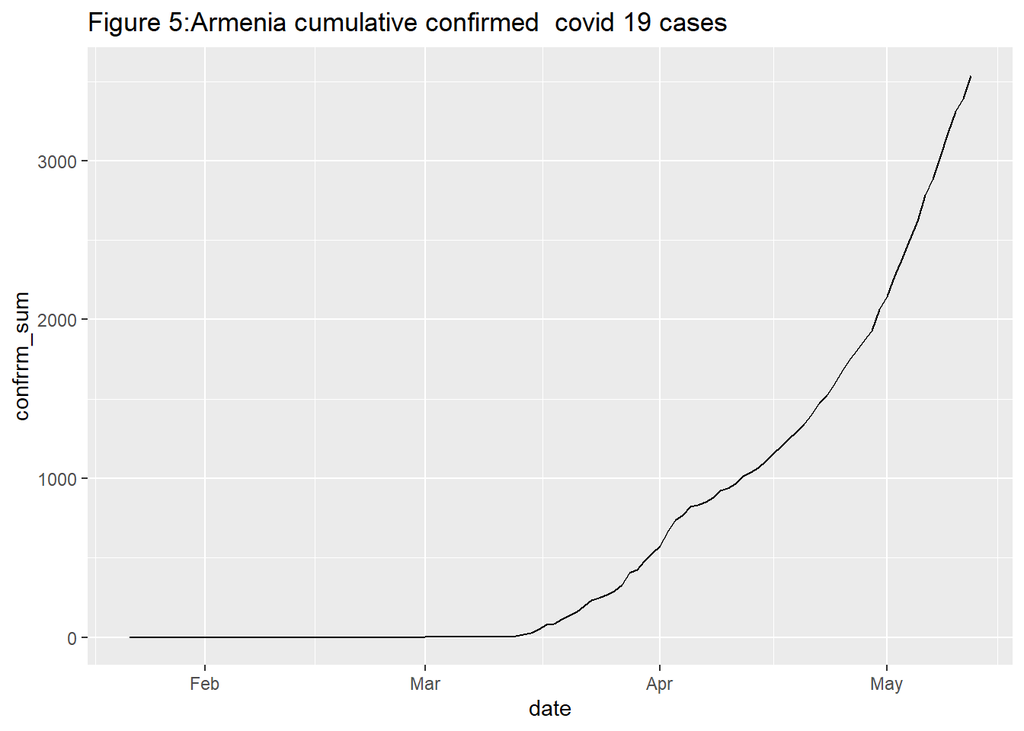

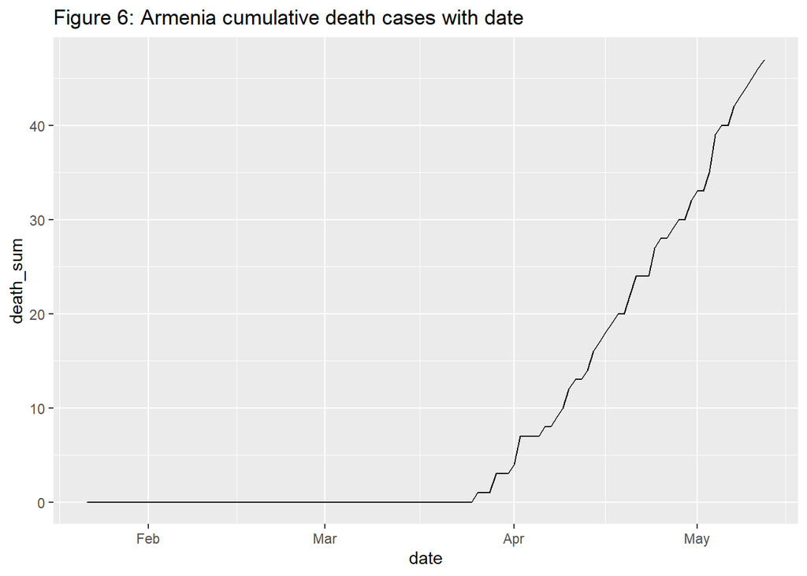

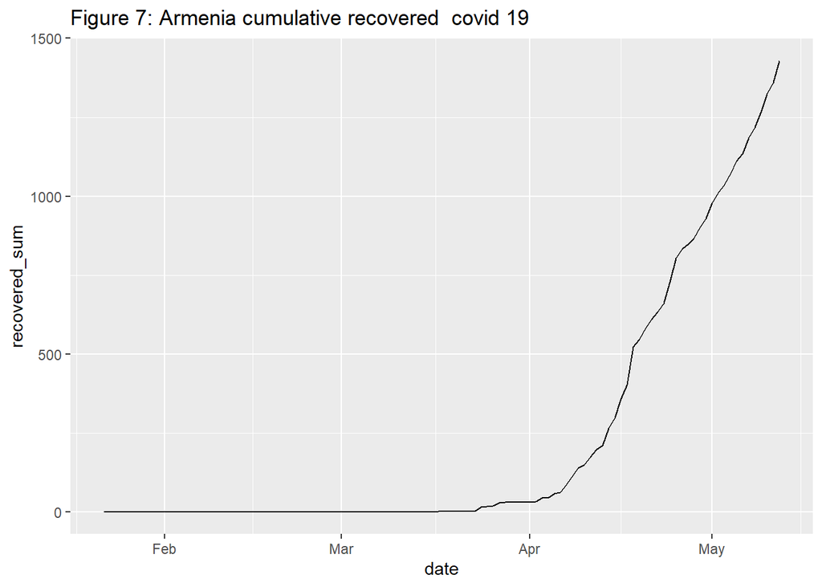

Figure 5 show that total covid 19 confirm cases were increased after middle of March. Total deaths were increased shortly at the end days of March (Figure 6).There were increment of total recoveries after April (Figure 7).

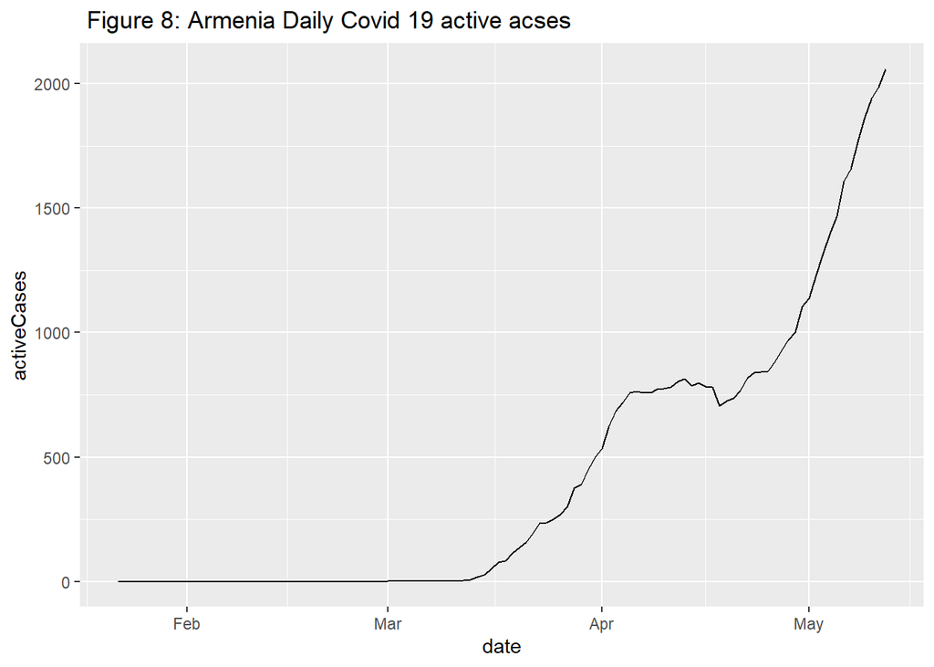

### Daily covid 19 status in Armenia and China

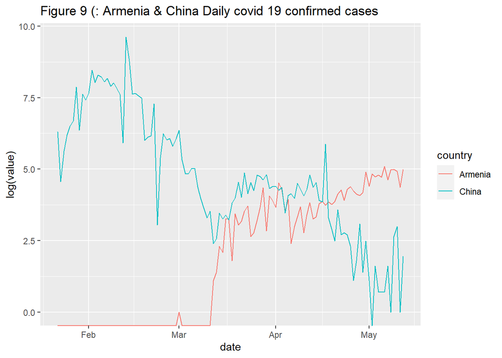

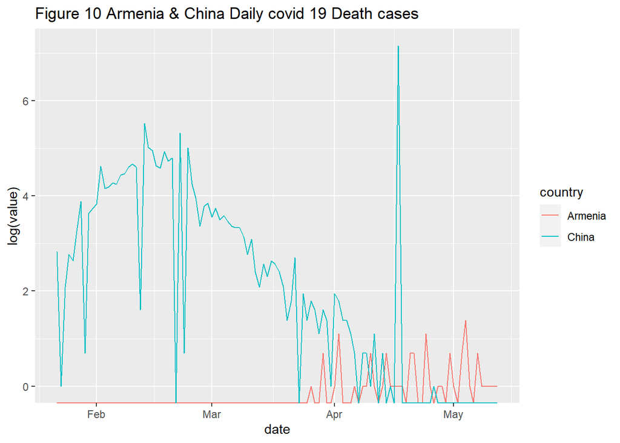

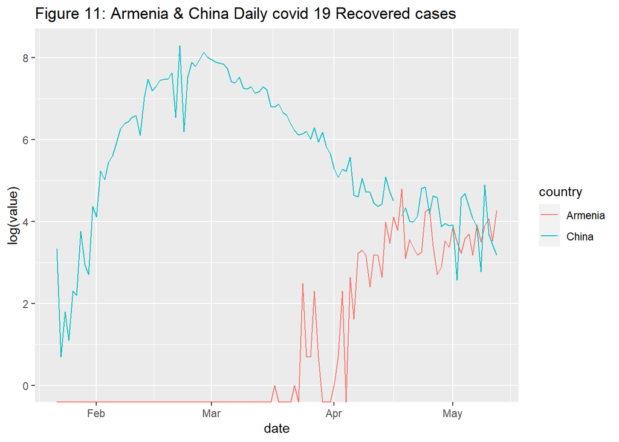

Figure 9 show that, In early days like January, February there were only china daily covid 19 confirm cases regarding Armenia after that there were approximately same daily confirm status but the confirmed cases were increased in Armenia after middle of April. Daily death cases were higher in China than Armenia before middle of the April (Figure 10) but Daily recovered distributed in same pattern after middle of April(Figure 11).

### Daily covid 19 status in Armenia and USA

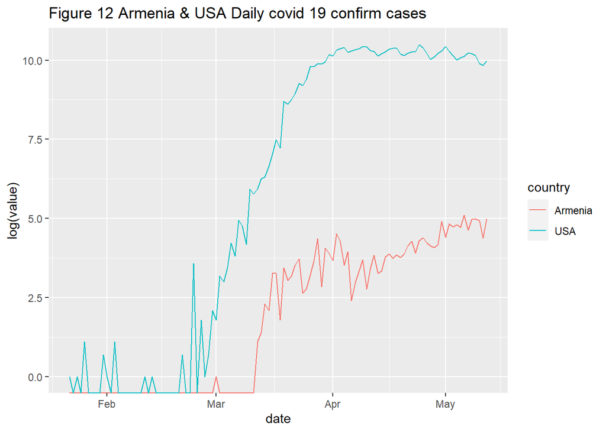

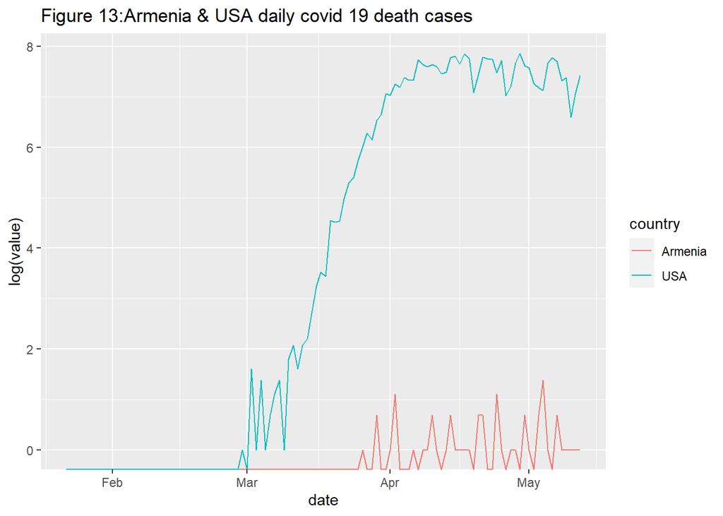

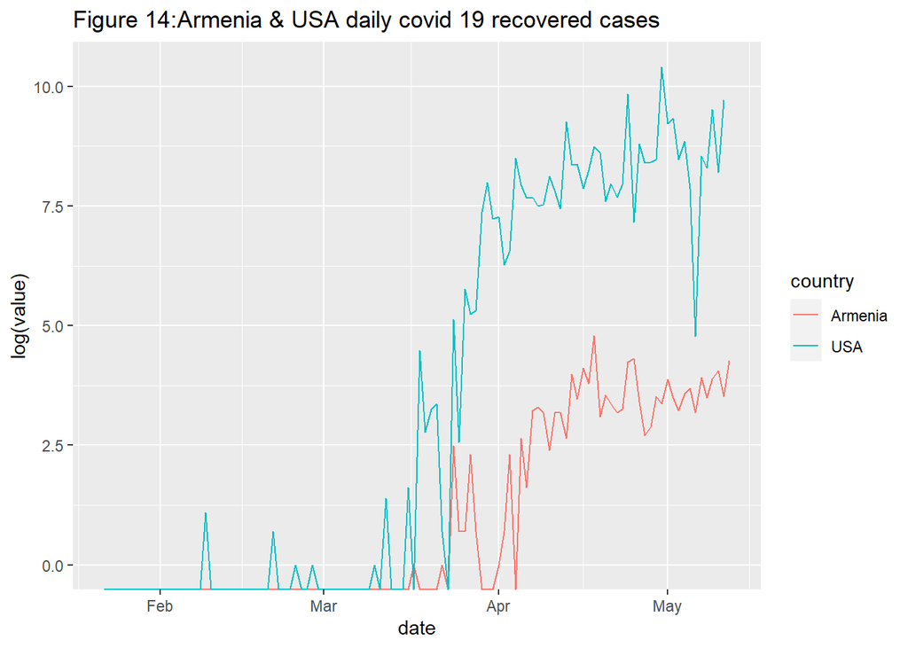

Above figure 12 show that USA daily confirmed cases are higher than Armenia. It started to increase at the beginning of March and after April their was not increment.Daily death cases also like confirmed cases but recovered cases not behave like that. Recovered cases had not higher increment like confirm and death cases (Figure 14).

### Daily covid 19 status in Armenia and Azerbaijan

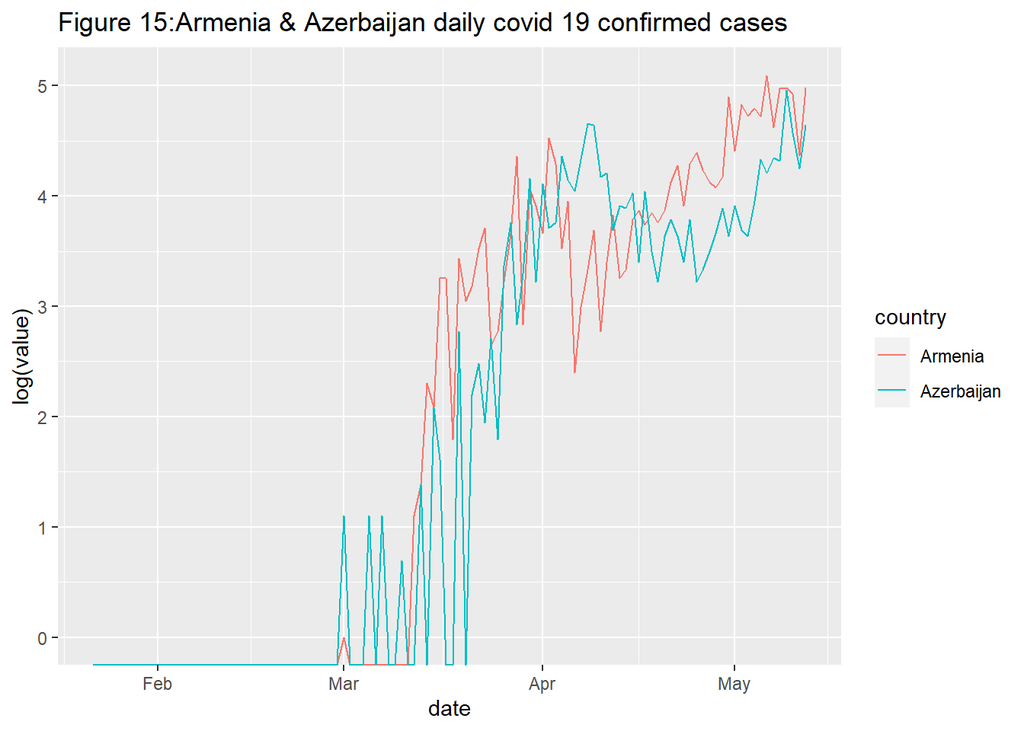

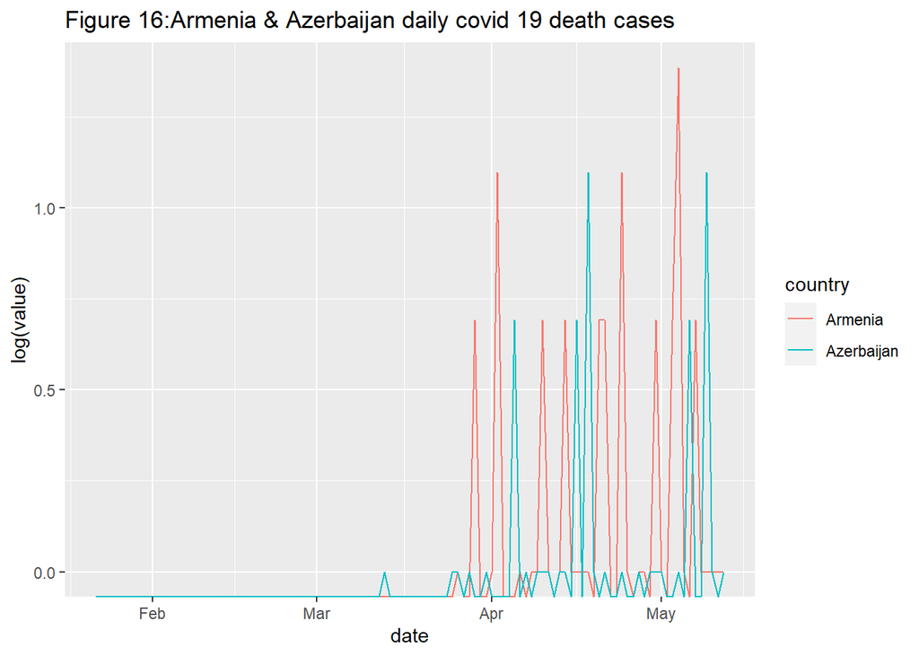

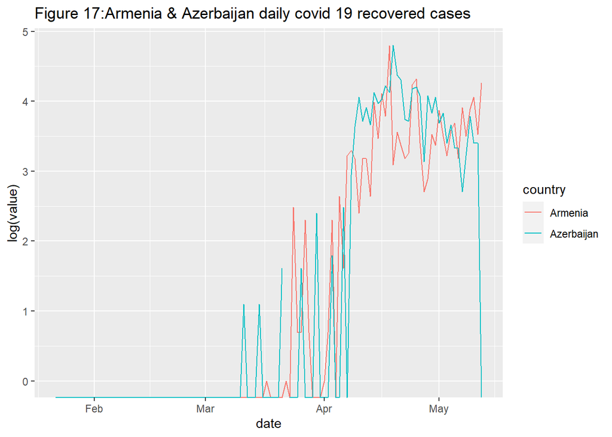

According to figure 15,16,17 we can say that Armenia and Azerbaijan daily covid 19 cases are distributed in same pattern that daily confirmed, death and recovered cases reported in same way.

### Total covid 19 status in different countries

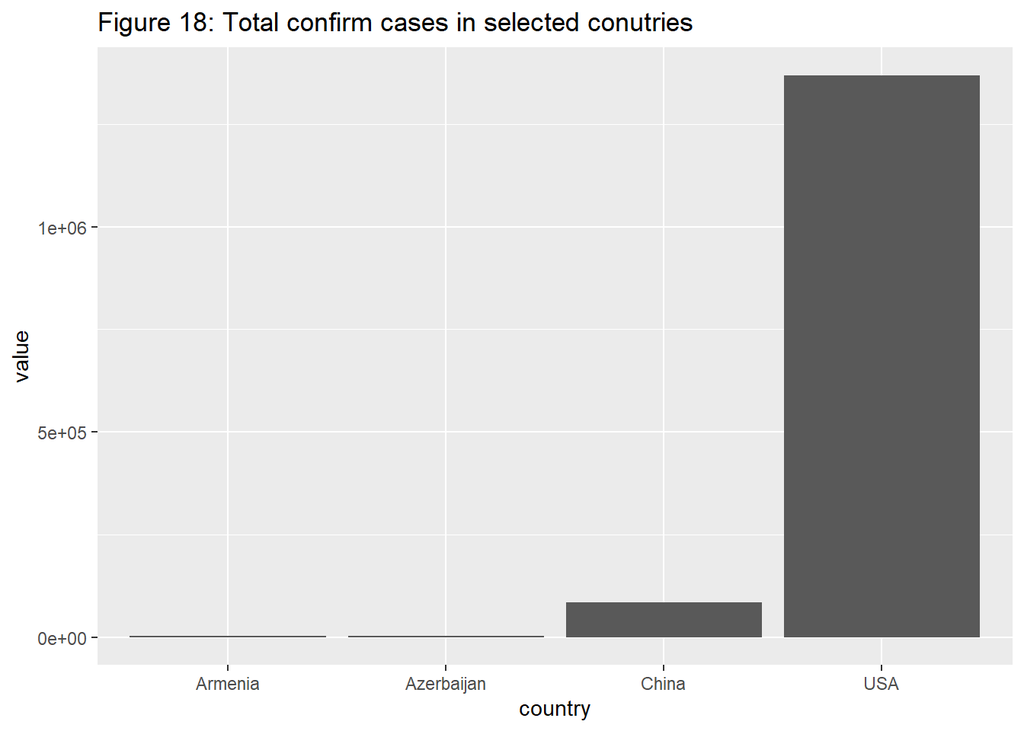

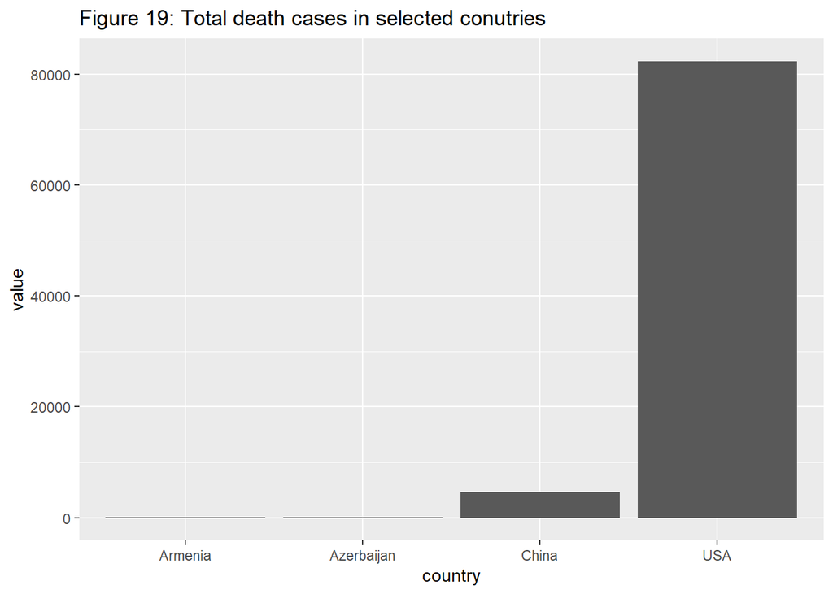

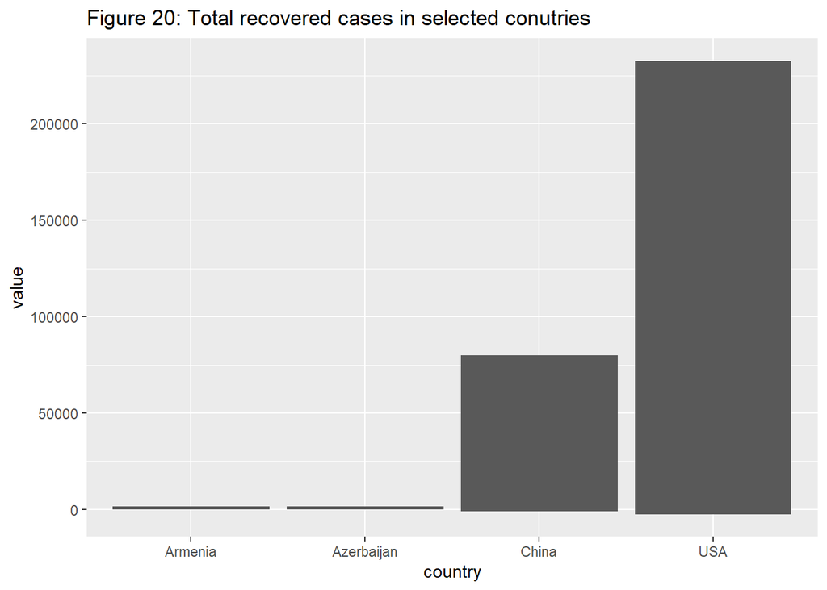

According to figure 18, 19 and 20 we can say that, total covid 19 status were highest in USA. Secondly higher cases were reported in China among these countries. Armenia and Azerbaijan show same covid 19 status.